# WeRateDogs Visual Analytics

## 01. Firstly, let's perform some visual analysis to identify the top 3 breeds.

### - What is the distribution of Pet lovers' rating, what rate they tend to give their close friends?

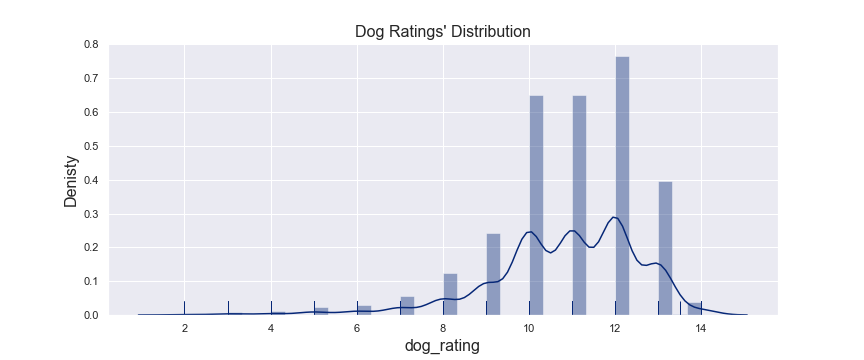

- It's obvious that dogs friends are very happy with them as the most of time they rated their dogs with at least **10** and most often to reach the score of **12**. Great!, it seems that we also a truthful friend to dogs, not dogs only.

### - What are the top 10 breeds based on average rating?

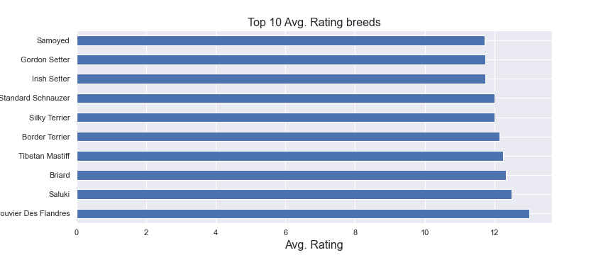

- Because of the most rating lied between **10** and **12**, we can see that the gap is very small between the top one and the 10th in the plot. But, we'll go further and test the rating distribution of the top10 for the seek of deep insights.

### - For the identified top ten breeds, what is the distribution of each breed rating?

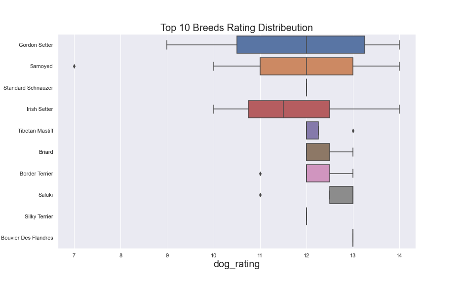

### - Which one of the top 3 breeds has the most fans in terms of "retweet_count" and "favorite_count"?

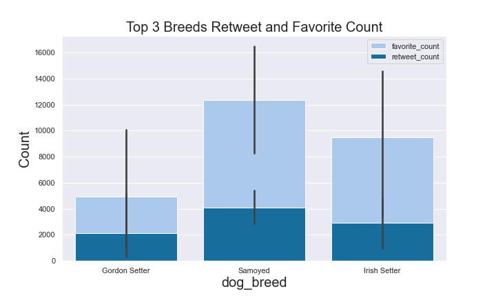

- Wow!, it seems obvious that our insights working precisely **Samoyed**, **Irish Setter**, and **Gordon Setter**, and, luckily, they take the same shape as the Olympic game ranking!.

### - Now, let's finish this perspective up and see what's the most common tweeting sources for each one of them?

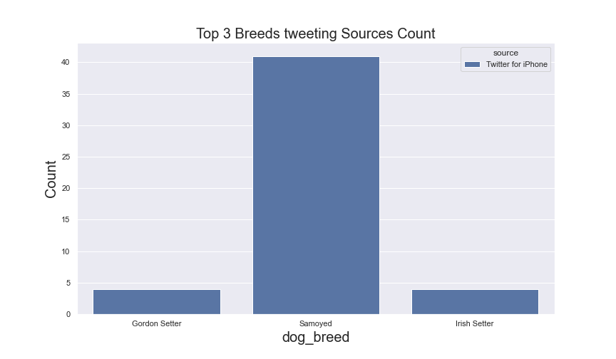

- For the top 3 breeds, **Twitter for iPhone** was the most common way for these breeds lovers to share their moments with them. But, obiviously, it proving that dog stage **Samoyed** the mentioned one.

## 02. Now, let's figure out the most mentioned dog-stage, dog-name, and the dog-stage with the highest retweet/favorite count.

### - What is the most common dog stage?

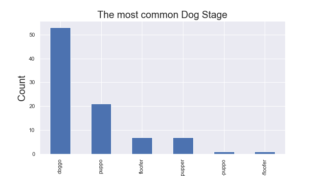

- Pet lovers preferred to breeding **Doggo** in the first stage and **Puppo** secondly.

### - Which Dog Stage has the most "Retweet" and "Favorite" count among the others?

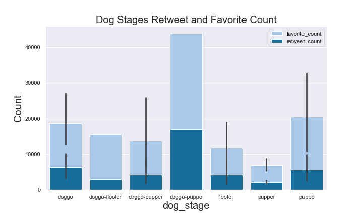

- While **Doggo** is the most mentioned dog stage but it isn't the most stage with neither **Retweet** nor **Favorite** count.
- Dog stage **Doggo-Puppo** is the most liked stage, followed by **Puppo** then **Doggo**. Surprisingly, it's almost the same stage.
- But, regarding the most retweeted, it shows that dog stage **Doggo-Puppo** comes first too, followed by **Doggo** then **Puppo**, but, with strong presence of **Floofer** and **Doggo-Pupper**.

### - What is the most frequent dog name?

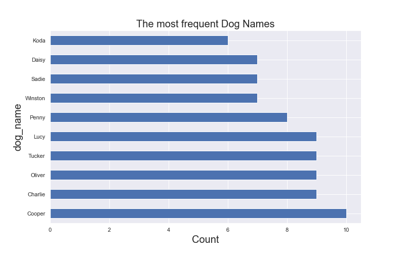

- **Cooper** comes first then **Charlie**, **Oliver**, **Tucker**, and **Lucy** seem to be the most frequent dog name. But, in the same time, **Penny** isn't far away from them.

## 03. Finally, I'll test if there any relation between retweet/favorite and what insight we can take from this finding, then, spotting the most words breeders used within their tweets and what insights these words can give us.

### - What is the corelation between "retweet count" and "favorite count"?

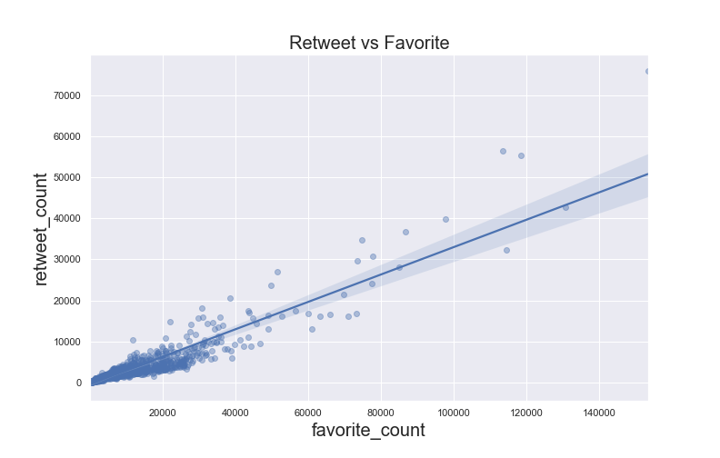

- Plot shows a very strong positive correlation between retweets and favorite count.
- It's reasonable and common sense that as the tweet gets more likes (favorites) it becomes more probable to retweet.

### - What words Dog Lovers used commonly to share their moments with their dogs?

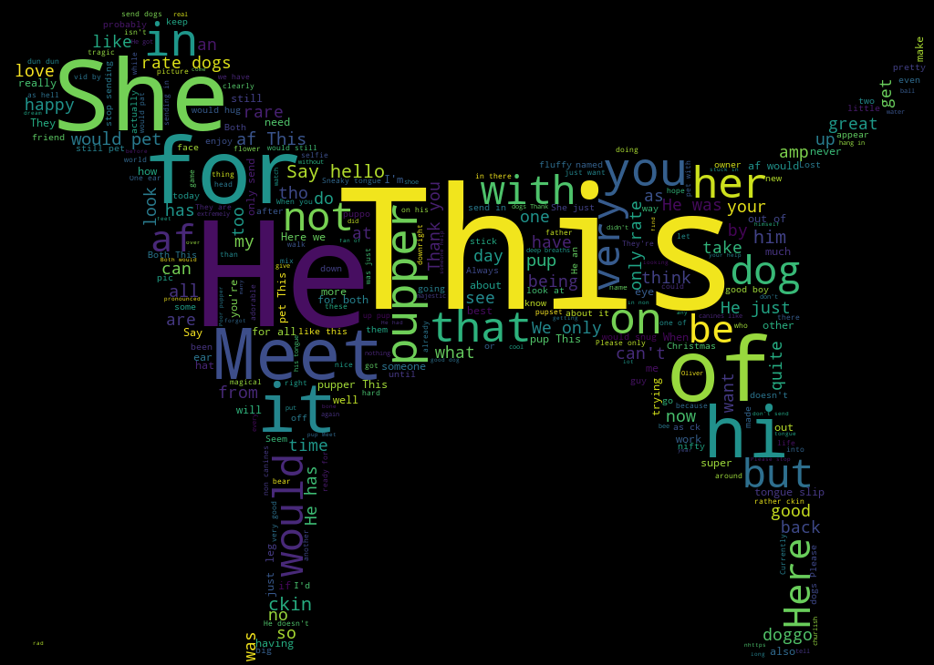